# SSASM Networks

# 1 Networks 1 Obi

## 1.1 Learning Objectives

What are the three main take aways from today?

- Defining graphs: nodes, edges and the adjacency matrix.
- Directed vs undirected graphs
- Connected graphs
- Calculating node degree
- Shortest paths and diameter
- Performing the above calculations on the London Tube network

Possible useful resource: https://kateto.net/wp-content/uploads/2016/01/NetSciX_2016_Workshop.pdf

## 1.2 Sample data

“A network is, in its simlpest form, a collection of points joined together in pairs by lines” M.E.J Newman, Networks, An Introduction

There are many systems that can be usefully thought of as networks. For example:

- The internet (computers joined together by data connections)
- Food webs (animals and plants joined by preditor-prey relationships)
- Transport networks (intersections joined by roads or stations joined by trains)
- Economic networks (businesses joined by transactions)

Consider hypothetical Twitter data. Each column representing who that person follows.

```r
dfTwitter <- data.frame("Bonnie" = c(0,0,0,1,1),
                        "Matt" = c(1,0,0,1,0),
                        "Elsa" = c(0,1,0,0,1),
                        "Neave" = c(1,0,0,0,0),
                        "Obi" = c(0,1,1,0,0),
                        row.names = c("Bonnie", "Matt", "Elsa", "Neave", "Obi"))

dfTwitter
```

```
##        Bonnie Matt Elsa Neave Obi
## Bonnie      0    1    0     1   0
## Matt        0    0    1     0   1
## Elsa        0    0    0     0   1
## Neave       1    1    0     0   0
## Obi         1    0    1     0   0
```

From this we see that Bonnie follows Neave and Obi, Matt follow Bonnie and Neave, etc…

Now create an iGraph graph object from this data

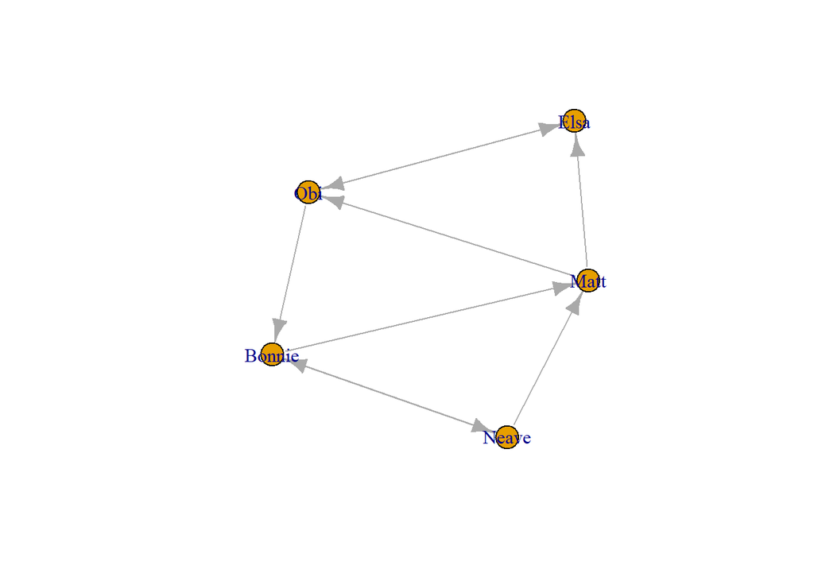

```r
graphTwitter <- graph_from_adjacency_matrix(as.matrix(dfTwitter))
plot(graphTwitter)
```

Some important definitions to introduce here are:

**Graph**

A Graph is a mathematical representation of a network, with n nodes and m edges, as seen above. In this example, the nodes represent Twitter accounts and the edges represent following relationships between the accounts.

Nodes (Vertices)

```r
V(graphTwitter)
```

```
## + 5/5 vertices, named, from 58d1c6b:
## [1] Bonnie Matt   Elsa   Neave  Obi
```

Edges

```r
E(graphTwitter)
```

```
## + 9/9 edges from 58d1c6b (vertex names):
## [1] Bonnie->Matt   Bonnie->Neave  Matt  ->Elsa   Matt  ->Obi
## [5] Elsa  ->Obi    Neave ->Bonnie Neave ->Matt   Obi   ->Bonnie
## [9] Obi   ->Elsa
```

An equivalent representation of this network is the edge list, with edges pointing from the nodes in columns 1 to the nodes in column 2.

```r
get.edgelist(graphTwitter)
```

```
##       [,1]     [,2]
##  [1,] "Bonnie" "Matt"
##  [2,] "Bonnie" "Neave"
##  [3,] "Matt"   "Elsa"
##  [4,] "Matt"   "Obi"
##  [5,] "Elsa"   "Obi"
##  [6,] "Neave"  "Bonnie"
##  [7,] "Neave"  "Matt"
##  [8,] "Obi"    "Bonnie"
##  [9,] "Obi"    "Elsa"
```

**Adjacency matrix**

Another equivalent, and frequently used representation of a network is the adjacency matrix.

In iGraph the convention for adjacency matrix elements is (some textbooks use the reverse convention)

$$A_{ij} = \begin{cases} 1, & \text{if there is an edge from node i to j}\\
0, & \text{otherwise}
\end{cases}$$

In this case, the dataframe used to create the network is essentially the adjacency matrix:

```r
get.adjacency(graphTwitter)
```

```
## 5 x 5 sparse Matrix of class "dgCMatrix"
##        Bonnie Matt Elsa Neave Obi
## Bonnie      .    1    .     1   .
## Matt        .    .    1     .   1
## Elsa        .    .    .     .   1
## Neave       1    1    .     .   .
## Obi         1    .    1     .   .
```

$A_{Bonnie,Matt} = 1$

```r
graphTwitter['Bonnie','Matt'] # as.matrix(get.adjacency(graphTwitter))['Bonnie','Matt'] also works
```

```
## [1] 1
```

**Directed Graph**

This is a directed graph meaning that node j might be connected to node i, but node i might not be connected to node j.

Directed graphs have adjacency matrices that are not symmetric

```r
isSymmetric(get.adjacency(graphTwitter))
```

```
## [1] FALSE
```

Bonnie is connected to Matt but Matt is not connected to Bonnie

```r
print(graphTwitter['Bonnie','Matt'])
```

```
## [1] 1
```

```r
print(graphTwitter['Matt','Bonnie'])
```

```
## [1] 0
```

## 1.3 Sample analysis

With the information about our social network represented as a Graph, we can perform some analysis.

**Node degree**

Undirected graph: the number of links attached to a node $k_i = \sum_{i=1}^{n}A_{ij} = \sum_{j=1}^{n}A_{ij}$

Directed graph: either the number of ‘in’ links or ‘out’ links attached to a node.

In degree of the Twitter Graph

```r
degree(graphTwitter, mode = "in")
```

```
## Bonnie   Matt   Elsa  Neave    Obi
##      2      2      2      1      2
```

Out degree

```r
degree(graphTwitter, mode = "out")
```

```
## Bonnie   Matt   Elsa  Neave    Obi
##      2      2      1      2      2
```

**Paths**

A path is a sequence of nodes such that each node is connected to the next node. For example: [‘Bonnie’, ‘Neave’, ‘Matt’, ‘Elsa’].

The shortest path is the shortest possible path between any two nodes.

[‘Bonnie’, ‘Neave’, ‘Matt’, ‘Elsa’] is a path from Bonnie to Elsa but the shortest path is…

```r
shortest_paths(graphTwitter, 'Bonnie', to = 'Elsa',
               mode = "out", weights = NULL, output = c("vpath", "epath", "both"),
               predecessors = FALSE, inbound.edges = FALSE)
```

```
## $vpath
## $vpath[[1]]
## + 3/5 vertices, named, from 58d1c6b:
## [1] Bonnie Matt   Elsa
##
##
## $epath
## NULL
##
## $predecessors
## NULL
##
## $inbound_edges
## NULL
```

or use mode=“in” to find the shortest path from the ‘to’ node to the ‘from’ node

```r
shortest_paths(graphTwitter, 'Bonnie', to = 'Elsa',
               mode = "in", weights = NULL, output = "vpath",
               predecessors = FALSE, inbound.edges = FALSE)
```

```
## $vpath
## $vpath[[1]]
## + 3/5 vertices, named, from 58d1c6b:
## [1] Bonnie Obi    Elsa
##
##
## $epath
## NULL
##
## $predecessors
## NULL
##
## $inbound_edges
## NULL
```

**Connected**

A Graph is connected if it is possible to reach any node from any other node. Directed graphs can be ‘strongly’ or ‘weakly’ connected.

- Strongly connected: it is possible to reach every node from every other node whilst following the directions of the edges
- Weakly connected: it is possible to reach every node only if the directions of the edges are disregarded (treat as undirected graph)

The Twitter graph is strongly connected (which means it is also weakly connected)

```r
is.connected(graphTwitter, mode = "strong")
```

```
## [1] TRUE
```

**Diameter**

The diameter of the network is the length of the longest shortest path.

```r
diameter(graphTwitter)
```

```
## [1] 3
```

For only weakly connected directed graphs the diameter is infinite (since it is not possible to connect some node pairs) and so a slightly different definition of diameter must be used.

## 1.4 Real World Example

Use GIS data of the London Underground to produce graph representing the tube network.

Stations -> Nodes Connections between stations -> Edges

**Read the shapefile data**

Linestrings with each end being the coordinates of a station

```r
dir_data <- ".\\data\\underground"
sfTube <- readOGR(dsn = dir_data, "underground")
```

The data contain line strings between the coordinates of tube stations

```r
head(sfTube@lines)
```

```
## [[1]]
## An object of class "Lines"
## Slot "Lines":
## [[1]]
## An object of class "Line"
## Slot "coords":
##         [,1]    [,2]
## [1,] -0.1571 51.5226
## [2,] -0.1631 51.5225
##
##
##
## Slot "ID":
## [1] "0"
##
##
## [[2]]
## An object of class "Lines"
## Slot "Lines":
## [[1]]
## An object of class "Line"
## Slot "coords":
##         [,1]    [,2]
## [1,] -0.1571 51.5226
## [2,] -0.1466 51.5234
##
##
##
## Slot "ID":
## [1] "1"
##
##
## [[3]]
## An object of class "Lines"
## Slot "Lines":
## [[1]]
## An object of class "Line"
## Slot "coords":
##         [,1]    [,2]
## [1,] -0.1247 51.5080
```

[output cut: 39 more lines]

```
##
## [[6]]
## An object of class "Lines"
## Slot "Lines":
## [[1]]
## An object of class "Line"
## Slot "coords":
##         [,1]    [,2]
## [1,] -0.1679 51.5199
## [2,] -0.1755 51.5154
##
##
##
## Slot "ID":
## [1] "5"
```

and attributes of the linestrings

```r
head(sfTube@data)
```

```
##   toid_seq station_1       station_1_ station_2       station_2_ distance
## 0        1        11     Baker Street       163       Marylebone 416.5861
## 1        2        11     Baker Street       212    Regent's Park 734.1736
## 2        3        49    Charing Cross        87       Embankment 179.5034
## 3        4        49    Charing Cross       197 Picadilly Circus 689.2898
## 4        5        82 Edgware Road (B)       163       Marylebone 441.2181
## 5        6        82 Edgware Road (B)       193       Paddington 727.2998
```

**Create a graph from the data**

Use the attribute data from the shape file to create a graph representing the tube network.

```r
dfTube <-  sfTube@data
dfTubeGraph <- data.frame(i = dfTube$station_1, j = dfTube$station_2, distance = dfTube$distance)
graphTube <- graph_from_data_frame(dfTubeGraph, directed = FALSE)
head(get.edgelist(graphTube))
```

```
##      [,1] [,2]
## [1,] "11" "163"
## [2,] "11" "212"
## [3,] "49" "87"
## [4,] "49" "197"
## [5,] "82" "163"
## [6,] "82" "193"
```

**Add node attribute to the graph**

Process the data to get the coordinates, names, and ids of all stations

```r
# fortify extracts x and y coordinates from the points that make up the linestrings and the id of the linestring the points belong to
sfTube.f=fortify(sfTube)

# Create id column that matches the ids of the linestrings
dfTube$id <- as.numeric(as.character(dfTube$toid_seq)) - 1

# Join the coordinates to the data from the shape file using the id column
dfMergedTube <- merge(sfTube.f, dfTube, by.x = "id", by.y = "id")

# Separate out the first and second stations and stack these on top of one another in one long dataframe.
firstStation <- dfMergedTube[dfMergedTube$order == 1,]
secondStation <- dfMergedTube[dfMergedTube$order == 2,]

firstStation <- data.frame(id=firstStation$station_1, name = firstStation$station_1_, lat = firstStation$lat, long = firstStation$long)
secondStation <- data.frame(id=secondStation$station_2, name = secondStation$station_2_, lat = secondStation$lat, long = secondStation$long)

dfStations <- rbind(firstStation, secondStation) %>% unique()
head(dfStations)
```

```
##     id               name     lat    long
## 1   11       Baker Street 51.5226 -0.1571
## 3  114 Harrow & Wealdston 51.5925 -0.3351
## 4    3       Aldgate East 51.5154 -0.0726
## 6   15            Barking 51.5396  0.0810
## 8   17       Barons Court 51.4905 -0.2139
## 10  18          Bayswater 51.5121 -0.1879
```

Find the index at which each vertex appears in the dataframe of stations and use this to assign names and positions to the verticies

```r
# Since the vertices don't have names yet, V(graphTube)$name returns a vector of vertex ids
v_pos = match(V(graphTube)$name, as.character(dfStations$id))

# Use the vector of positions to get the node names and coordinates ordered the same as they are in the graph
vector_names <- dfStations$name[v_pos]
vector_coords <- dfStations[v_pos,]

graphTube <- set.vertex.attribute(graphTube, "name", index = V(graphTube), value = as.character(vector_names))
graphTube <- set.vertex.attribute(graphTube, "x", index = V(graphTube), value = as.numeric(vector_coords$long))
graphTube <- set.vertex.attribute(graphTube, "y", index = V(graphTube), value = as.numeric(vector_coords$lat))
```

Nodes now all have name, x, and y attributes

```r
print(get.vertex.attribute(graphTube, "name", 11))
```

```
## [1] "Lambeth North"
```

```r
print(get.vertex.attribute(graphTube, "x", 11))
```

```
## [1] -0.1115
```

```r
print(get.vertex.attribute(graphTube, "y", 11))
```

```
## [1] 51.4991
```

## 1.5 Numeric Results

This graph is undirected and connected.

```r
print(isSymmetric(get.adjacency(graphTube)))
```

```
## [1] TRUE
```

```r
print(is.connected(graphTube))
```

```
## [1] TRUE
```

The graph includes an edge attribute for each edge - ‘distance’ - taken from the distance between stations

```r
get.edge.attribute(graphTube)$distance[1:10]
```

```
##  [1]  416.5861  734.1736  179.5034  689.2898  441.2181  727.2998  954.9616
##  [8]  698.0515 1537.3971  783.2256
```

Show adjacency matrix with and without weights (topographic vs weighted)

For cases where there are multiple edges between nodes, the inclusion of weights can be misleading.

```r
get.adjacency(graphTube)[1:10,1:10]
```

```
## 10 x 10 sparse Matrix of class "dgCMatrix"
```

```
##    [[ suppressing 10 column names 'Baker Street', 'Charing Cross', 'Edgware Road (B)' ... ]]
```

```
##
## Baker Street       . . . . . . . . . .
## Charing Cross      . . . . 2 . . . . .
## Edgware Road (B)   . . . . . . . . . .
## Elephant & Castle  . . . . . . . . . .
## Embankment         . 2 . . . . . . . .
## Harlesden          . . . . . . . . . .
## Harrow & Wealdston . . . . . . . . 1 .
## Kensal Green       . . . . . . . . . .
## Kenton             . . . . . . 1 . . .
## Kilburn Park       . . . . . . . . . .
```

```r
get.adjacency(graphTube, attr = "distance")[1:10,1:10]
```

```
## 10 x 10 sparse Matrix of class "dgCMatrix"
```

```
##    [[ suppressing 10 column names 'Baker Street', 'Charing Cross', 'Edgware Road (B)' ... ]]
```

```
##
## Baker Street       .   .      . .   .      .    .     .    .     .
## Charing Cross      .   .      . . 359.0068 .    .     .    .     .
## Edgware Road (B)   .   .      . .   .      .    .     .    .     .
## Elephant & Castle  .   .      . .   .      .    .     .    .     .
## Embankment         . 359.0068 . .   .      .    .     .    .     .
## Harlesden          .   .      . .   .      .    .     .    .     .
## Harrow & Wealdston .   .      . .   .      .    .     . 1785.108 .
## Kensal Green       .   .      . .   .      .    .     .    .     .
## Kenton             .   .      . .   .      . 1785.108 .    .     .
## Kilburn Park       .   .      . .   .      .    .     .    .     .
```

From this we see there are two connections between station 87 and 49. Check this in the data.

```r
dfTube[dfTube$station_1 == 49,]
```

```
##     toid_seq station_1    station_1_ station_2       station_2_ distance
## 2          3        49 Charing Cross        87       Embankment 179.5034
## 3          4        49 Charing Cross       197 Picadilly Circus 689.2898
## 276      277        49 Charing Cross        87       Embankment 179.5034
## 277      278        49 Charing Cross       151 Leicester Square 436.4846
##      id
## 2     2
## 3     3
## 276 276
## 277 277
```

**Degree distribution**

Calculate degree distribution of the tube network

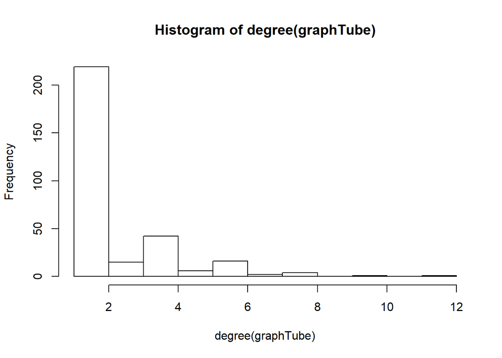

**Shortest paths and diameter**

A connected graph is one in which every node can be reached by every other node.

Calculate the shortest path between nodes (crude since the weights are distances and not travel times)

```r
startNode = V(graphTube)["Stockwell"]
endNode = V(graphTube)["Mile End"]
shortest_paths(graphTube, startNode, to = endNode, weights = get.edge.attribute(graphTube)$distance, output = "vpath")
```

```
## $vpath
## $vpath[[1]]
## + 12/306 vertices, named, from 5969d8c:
##  [1] Stockwell         Oval              Kennington
##  [4] Elephant & Castle Borough           London Bridge
##  [7] Bank              Liverpool Street  Aldgate East
## [10] Whitechapel       Stepney Green     Mile End
##
##
## $epath
## NULL
##
## $predecessors
## NULL
##
## $inbound_edges
## NULL
```

Calculate the diameter with and without using the distance as the weight.

```r
print(diameter(graphTube, directed = FALSE, unconnected = FALSE, weights = NULL))
```

```
## [1] 38
```

```r
print(diameter(graphTube, directed = FALSE, unconnected = FALSE, weights = get.edge.attribute(graphTube)$distance))
```

```
## [1] 71491.12
```

Plot the graph

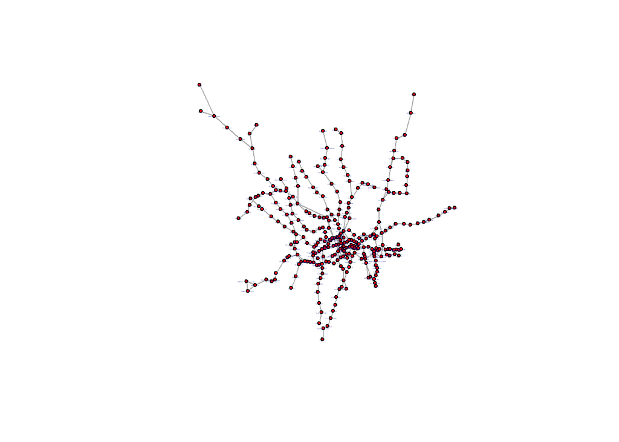

```r
graphTube=simplify(graphTube,remove.loops = T,remove.multiple = T,edge.attr.comb = "min")
plot(graphTube,vertex.size=3,vertex.color="red",vertex.label.cex=.1)
```

## 1.6 Further Reading

Resources from a workshop on networks and iGraph: https://kateto.net/wp-content/uploads/2016/01/NetSciX_2016_Workshop.pdf

[Rmarkdown Cheatsheet](https://www.rstudio.com/wp-content/uploads/2015/02/rmarkdown-cheatsheet.pdf)

# 2 Networks 2 Elsa

## 2.1 Learning Objectives

- Introduce two centrality measures: closeness centrality and betweeness centrality
- Calculate these centrality measures for the karate club dataset
- Introduce hierarchical clustering for community detection
- Apply hierarchical clustering to the karate club dataset
- Produce network from OSM data
- Calculate centrality measures on this road network

## 2.2 Centrality

Centrality is a measure of node importance.

There are many different centrality measures: * Eigenvector centrality * Katz Centrality * Closeness centrality * Betweeness centrality

Here we introduce Closeness and Betweenness Centrality

**Closeness centrality**

Let $d_{ij}$ be the geodesic distance (shortest path) between node i and j. The mean geodesic distance of node i is given by:
$$l_{i} = \frac{1}{n}\sum_{j}d_{ij}$$

The closenesscentrality of node i is defined as:
$$C_{i} = \frac{1}{l_{i}} = \frac{n}{\sum_{j}d_{ij}}$$

**Betweenness centrality**

Define $n^{i}_{st}$ as:
$$n^{i}_{st} = \begin{cases} 1, & \text{if vertex i lies on the geodesic path from s to t}\\
0, & \text{otherwise}
\end{cases}$$

Then betweenness centrality can be defined as:
$$x_{i} = \sum_{st}n^{i}_{st}$$

However, there may be multiple geodesics from s to t so to account for this we normalise by the number of geodesics from s to t, $g_{st}$:
$$x_{i} = \sum_{st}\frac{n^{i}_{st}}{g_{st}}$$

## 2.3 Sample data

Load Karate club graph

## 2.4 Hierarchical clustering

Steps to hierarchical clustering using centrality

1. Define centrality measure
2. Commpute centrality measure
3. Iteratively remove edges based on centrality until all links are removed
4. Identify set of disconnected components that maximise modularity - these are the communities

## 2.5 Real world example

Calculating centrality measures on road network, how to interpret these.

# 3 Networks 3 Neave

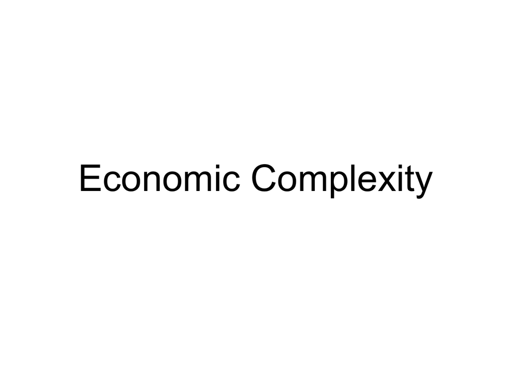

## 3.1 Learning Objectives

What are the three main take aways from this session?

- Understand how trade data can be used to model the capabilities of countries
- Calculate Relative Compatative Advantage (RCA) for a country and product
- Understand Product Space and how to use RCA to compute the proximity between products

The analysis presented here follows the paper *The Product Space Conditions the Development of Nations* By C. A. Hidalgo, B. Klinger, A.-L. Barabási, R. Hausmann, Science Jul 2007

It’s a great paper and worth a read.

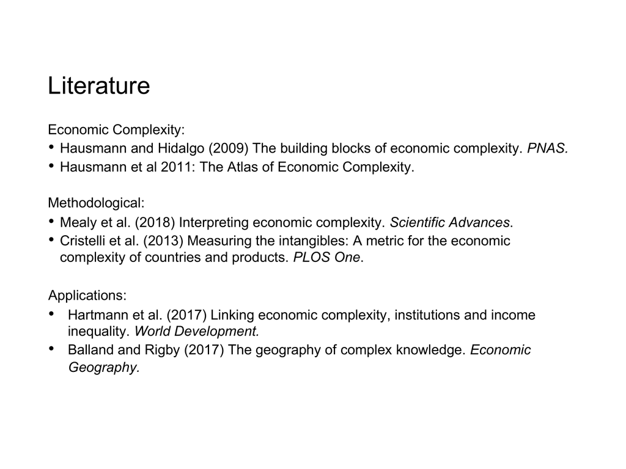

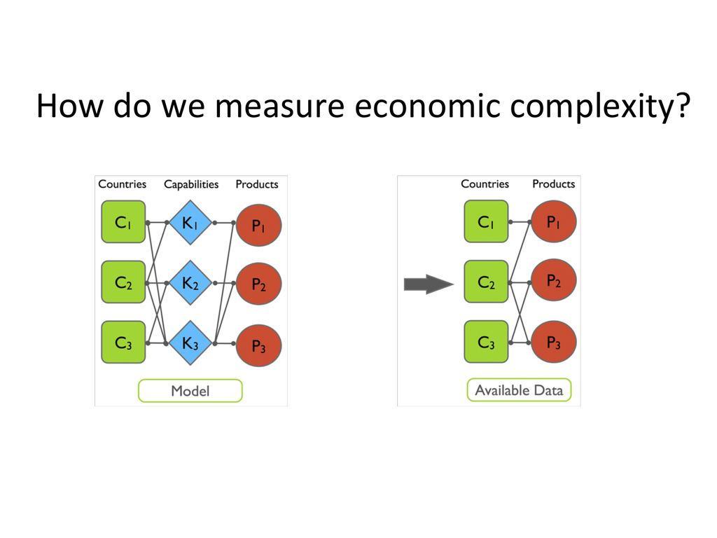

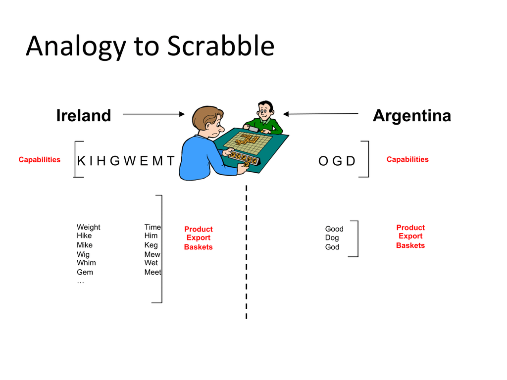

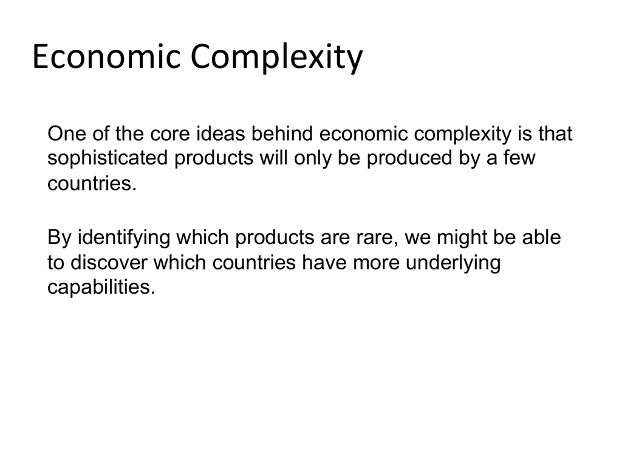

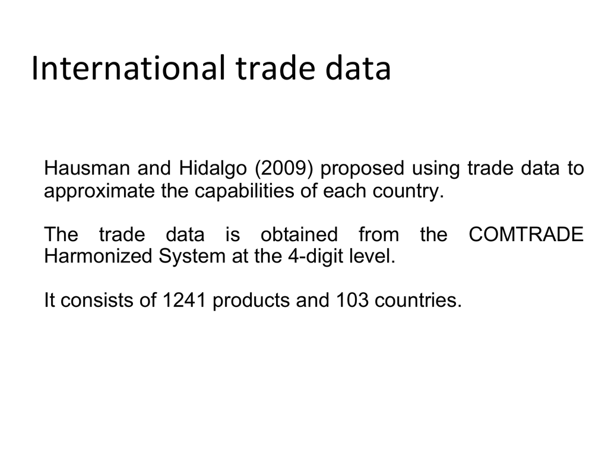

## 3.2 Trade Data

Access world import and export data from the United Nations here: https://cid.econ.ucdavis.edu/nberus.html.

See page 48 of the documentation (.\data\wtf99\NBER-UN_Data_Documentation_w11040.pdf) for an explanation of the variables.

```r
# Load world import and export data from 1999
wtf_data <- ".\\data\\wtf99\\wtf99.dta"
dfWorldTrade <- read.dta13(wtf_data)
head(dfWorldTrade)
```

```
##   year  icode importer  ecode exporter sitc4 unit dot   value quantity
## 1 1999 100000    World 100000    World             NA 3854744       NA
## 2 1999 100000    World 100000    World  0011       NA 1041246       NA
## 3 1999 100000    World 100000    World  0011    N  NA  388392  1970655
## 4 1999 100000    World 100000    World  0011    W  NA 2537670  1357983
## 5 1999 100000    World 100000    World  0012       NA   36635       NA
## 6 1999 100000    World 100000    World  0012    N  NA   36197   669442
```

Products are differentiated by their sitc4 code

```r
# 1263 different product codes includes 1 blank code so 1262 in reality
length(unique(dfWorldTrade$sitc4))
```

```
## [1] 1263
```

```r
# 188 unique exporter countries
length(unique(dfWorldTrade$ecode))
```

```
## [1] 188
```

Some data cleaning steps here

```r
# Remove invalid product codes and select only the columns we are interested in
dfWorldTrade <- dfWorldTrade[dfWorldTrade$sitc4 !="",c("ecode","sitc4","value")]
head(dfWorldTrade)
```

```
##    ecode sitc4   value
## 2 100000  0011 1041246
## 3 100000  0011  388392
## 4 100000  0011 2537670
## 5 100000  0012   36635
## 6 100000  0012   36197
## 7 100000  0012  725929
```

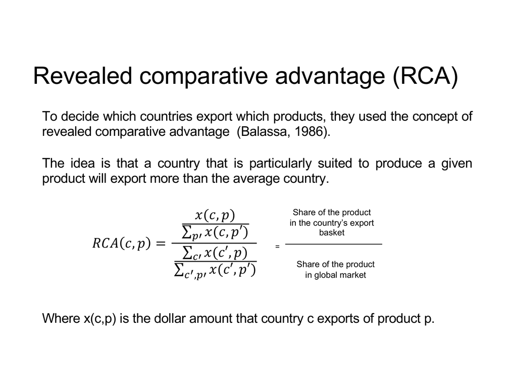

## 3.3 Revealed Comparative Advantage

Group by country and product and calculate the value of each county’s exports by product

```r
# Aggregate the data
dfWTCountryAgg <- aggregate(dfWorldTrade$value, by = list(dfWorldTrade$ecode), sum, na.rm = TRUE)
dfWTCountryProdAgg <- aggregate(dfWorldTrade$value, by = list(dfWorldTrade$ecode, dfWorldTrade$sitc4), sum, na.rm = TRUE)
dfWTProductAgg <- aggregate(dfWorldTrade$value, by = list(dfWorldTrade$sitc4), sum, na.rm = TRUE)
globalSum <- sum(dfWorldTrade$value)

# Rename the columns
colnames(dfWTCountryAgg) <- c("ecode", "etotal")
colnames(dfWTProductAgg) <- c("sitc4", "ptotal")
colnames(dfWTCountryProdAgg) <- c("ecode", "sitc4", "eptotal")
```

```r
head(dfWTCountryAgg)
```

```
##    ecode      etotal
## 1 100000 11574808360
## 2 117100    63359546
## 3 130120    26996016
## 4 134340    17184250
## 5 135040    16460714
## 6 137360     1173686
```

```r
head(dfWTProductAgg)
```

```
##   sitc4   ptotal
## 1  0011 15869232
## 2  0012  3195044
## 3  0013  4993484
## 4  0014  3628672
## 5  0015  6494916
## 6  0019     3840
```

```r
head(dfWTCountryProdAgg)
```

```
##    ecode sitc4 eptotal
## 1 100000  0011 7934616
## 2 117100  0011    4524
## 3 167060  0011   16028
## 4 211240  0011 1456330
## 5 218400  0011  422514
## 6 330320  0011    7852
```

Join these datasets together and use this to calculate RCA

```r
dfRCA <- merge(dfWTCountryProdAgg, dfWTCountryAgg, by ="ecode")
dfRCA <- merge(dfRCA, dfWTProductAgg, by="sitc4")
dfRCA$prod_in_country_share <-  dfRCA$eptotal / dfRCA$etotal
dfRCA$prod_in_global_share <- dfRCA$ptotal / globalSum
dfRCA$rca = dfRCA$prod_in_country_share / dfRCA$prod_in_global_share
head(dfRCA)
```

```
##   sitc4  ecode eptotal      etotal   ptotal prod_in_country_share
## 1  0011 100000 7934616 11574808360 15869232          6.855073e-04
## 2  0011 587030   15806    21150312 15869232          7.473176e-04
## 3  0011 533800   75956   457395020 15869232          1.660621e-04
## 4  0011 457640    1464   130220814 15869232          1.124244e-05
## 5  0011 117100    4524    63359546 15869232          7.140203e-05
## 6  0011 908960     246     3734816 15869232          6.586670e-05
##   prod_in_global_share        rca
## 1         0.0006855073 1.00000000
## 2         0.0006855073 1.09016716
## 3         0.0006855073 0.24224708
## 4         0.0006855073 0.01640018
## 5         0.0006855073 0.10415939
## 6         0.0006855073 0.09608460
```

RCA > 1 means that this product makes up a greater share of this country’s exports than the “average” country.

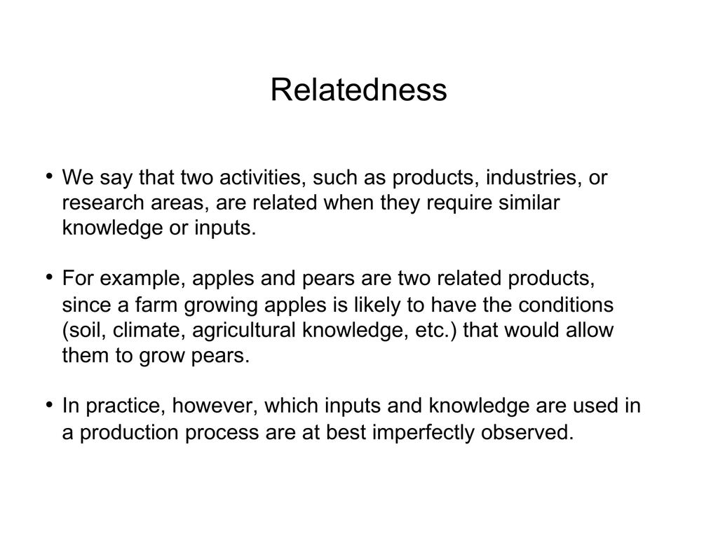

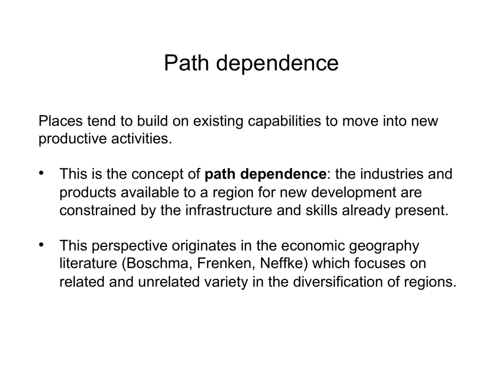

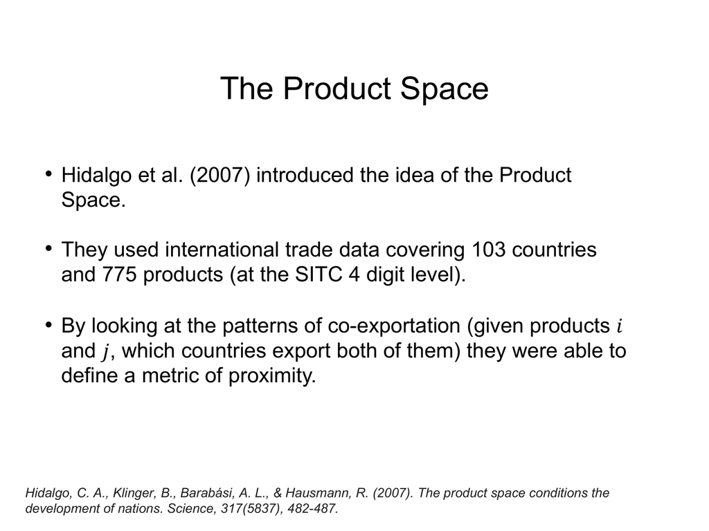

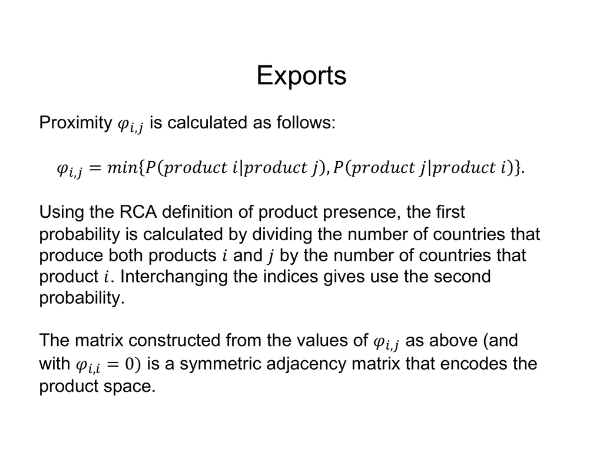

## 3.4 The Product Space

To calculate the proximity between products we use RCA as an indication of whether a country exports a product or not. If a country has an RCA > 1 for a product it is considered to export that product.

Using this the coditional probability of a product being exported given another product being exported is given by:

$$P(product_{i} | product_{j}) = \frac{\text{number of countries exporting i and j}}{\text{number of countries exporting j}}$$

```r
# Number of counties exporting each product
dfRCA$is_exported <- as.numeric(dfRCA$rca > 1)
dfNExport <- aggregate(dfRCA$is_exported, by = list(dfRCA$sitc4), sum)
head(dfNExport)
```

```
##   Group.1  x
## 1    0011 21
## 2    0012 24
## 3    0013 13
## 4    0014 15
## 5    0015 20
## 6    0019  4
```

```r
# Number of countries exporting product paris
# This block takes a long time to run. To save time (and avoid crashing your computer), you can read the data from csv using the next block instead.

#dfPairs <- merge(dfRCA, dfRCA, by = "ecode")
#dfPairs$joint_export <-  as.numeric((dfPairs$is_exported.x == 1) & (dfPairs$is_exported.y ==1))
#dfNJointExport <- aggregate(dfPairs$joint_export, by = list(dfPairs$sitc4.x,dfPairs$sitc4.y), sum)
#write.csv(dfNJointExport, ".\\data\\product_joint_export_counts.csv", row.names=FALSE)
#head(dfNJointExport)
```

```r
dfNJointExport <- read.csv(".\\data\\product_joint_export_counts.csv")
head(dfNJointExport)
```

```
##   Group.1 Group.2  x
## 1    0011    0011 21
## 2    0012    0011  9
## 3    0013    0011  5
## 4    0014    0011  4
## 5    0015    0011  6
## 6    0019    0011  1
```

Use these two tables to computer the conditional probabilities

```r
dfConditional <- merge(dfNJointExport, dfNExport, by = 'Group.1')
dfConditional$pij <- dfConditional$x.x / dfConditional$x.y
head(dfConditional)
```

```
##   Group.1 Group.2 x.x x.y        pij
## 1    0011    0011  21  21 1.00000000
## 2    0011    7372   6  21 0.28571429
## 3    0011    0572   5  21 0.23809524
## 4    0011    5139   9  21 0.42857143
## 5    0011    515A   1  21 0.04761905
## 6    0011    741X   4  21 0.19047619
```

Now identify and select the minimum joint probability by joining the data frame of confitional probabilities to itself.

```r
# Merge the dfConditional dataframe to itself so that we can compare the joint probabilities P(export i | export j) to P(export j | export i)
dfProximity <- merge(dfConditional, dfConditional, by.x = c("Group.1","Group.2"), by.y = c("Group.2", "Group.1"))
dfProximity$pij.x.islower <- dfProximity$pij.x < dfProximity$pij.y
head(dfProximity)
```

```
##   Group.1 Group.2 x.x.x x.y.x      pij.x x.x.y x.y.y     pij.y
## 1    0011    0011    21    21 1.00000000    21    21 1.0000000
## 2    0011    0012     9    21 0.42857143     9    24 0.3750000
## 3    0011    0013     5    21 0.23809524     5    13 0.3846154
## 4    0011    0014     4    21 0.19047619     4    15 0.2666667
## 5    0011    0015     6    21 0.28571429     6    20 0.3000000
## 6    0011    0019     1    21 0.04761905     1     4 0.2500000
##   pij.x.islower
## 1         FALSE
## 2         FALSE
## 3          TRUE
## 4          TRUE
## 5          TRUE
## 6          TRUE
```

```r
# We can check this merge has given us the right thing by checking the conditional probability value for Group.1 = "0015" and Group.2 = "0011" has been merged with the value for Group.1 = "0011" and Group.2 = "0015"
dfConditional[(dfConditional$Group.1=="0015") & (dfConditional$Group.2 == "0011"),]
```

```
##      Group.1 Group.2 x.x x.y pij
## 6299    0015    0011   6  20 0.3
```

```r
# Now select the lower conditional probabilities. The lower conditional probability is used as the proximity between two products
dfProximity1 <- dfProximity[dfProximity$pij.x.islower ==TRUE, c("Group.1", "Group.2", "pij.x")]
dfProximity2 <- dfProximity[dfProximity$pij.x.islower ==FALSE, c("Group.1", "Group.2", "pij.y")]

colnames(dfProximity1) <- c("product1","product2", "proximity")
colnames(dfProximity2) <- c("product1","product2", "proximity")

dfProximity <- rbind(dfProximity1, dfProximity2)

# Drop entries where product1 == product2 as the proximity is trivally 1
dfProximity <- dfProximity[dfProximity$product1!=dfProximity$product2,]

# Check for duplicates
any(duplicated(dfProximity[,1:2]))
```

```
## [1] FALSE
```

This dataframe can be used to build a network where the nodes are the products and the edge weights between products are the proximity.

```r
head(dfProximity)
```

```
##    product1 product2  proximity
## 3      0011     0013 0.23809524
## 4      0011     0014 0.19047619
## 5      0011     0015 0.28571429
## 6      0011     0019 0.04761905
## 10     0011     0112 0.19047619
## 11     0011     0113 0.38095238
```

Create an iGraph object from this edge list

```r
graphProdSpace <- graph_from_data_frame(dfProximity, directed = FALSE)
```

This is a very dense graph so plotting the whole thing will not be helpful. Instead lets look at teh Minimum Spanning Tree

```r
# Find the minimum spanning tree of this graph (really want maximum so would need to invert weights)
graphMST <- minimum.spanning.tree(graphProdSpace, weights = get.edge.attribute(graphProdSpace)$proximity)
```

Even this is not particularly helpful

[figure not shown]

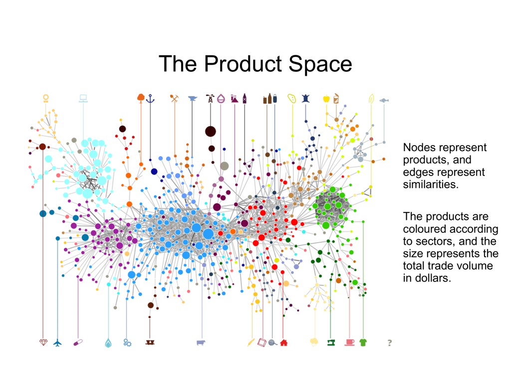

[figure not shown]

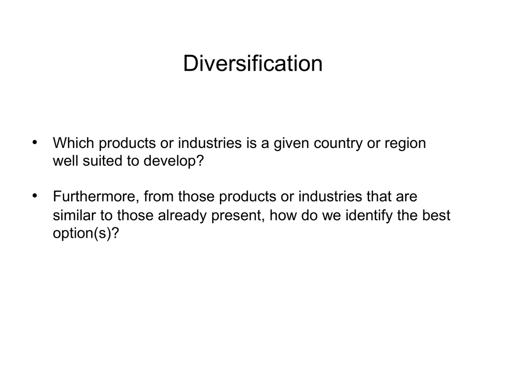

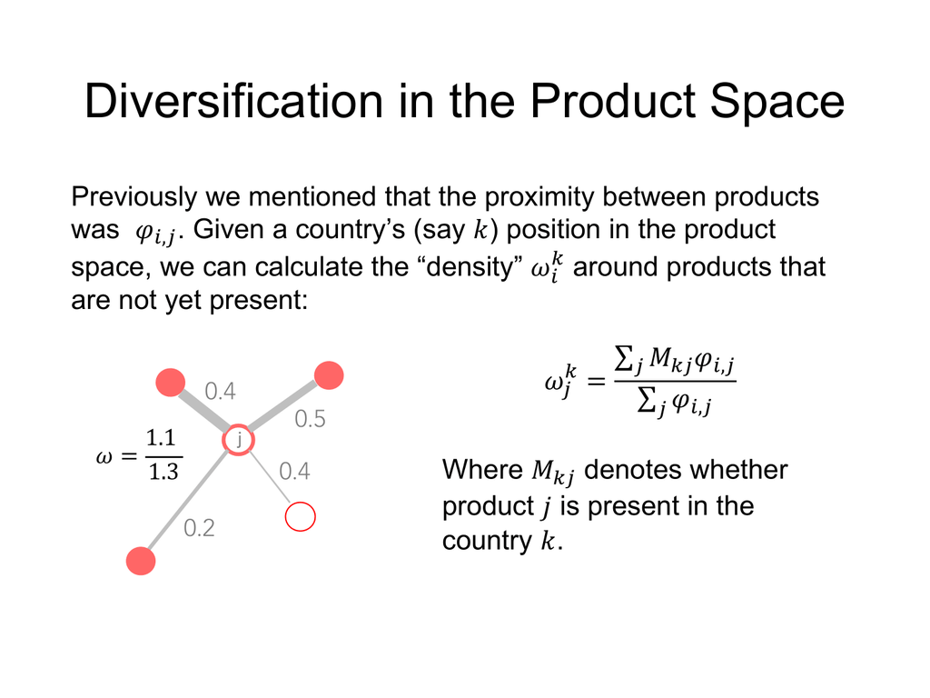

```r
plot(graphMST, vertex.size=3,vertex.color="red",vertex.label.cex=.1, )
```